# 시각화

##### 4.1.2 add lines and points

- 선의 모양 선택
  - lty=0, lty=“blank” 투명선
  - lty=1, lty=“solid” 실선
  - lty=2, lty=“dashed” 대쉬선
  - lty=3, lty=“dotted” 점선
  - lty=4, lty=“dotdash” 점선과 대쉬선
  - lty=5, lty=“longdash” 긴 대쉬선
  - lty=6, lty=“twodash” 2개의 대쉬선

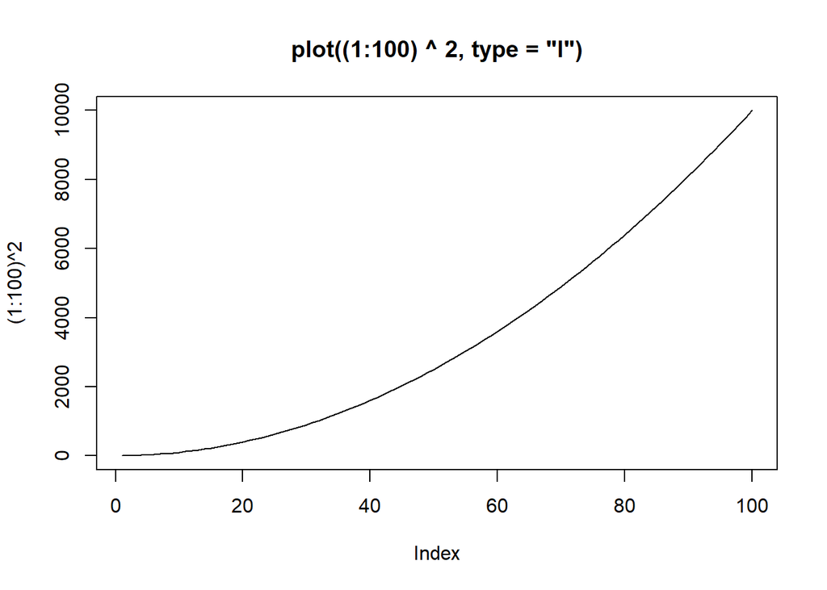

```r
plot(
  (1:100) ^ 2,
  type = "l",
  main = 'plot((1:100) ^ 2, type = "l")'
)
```

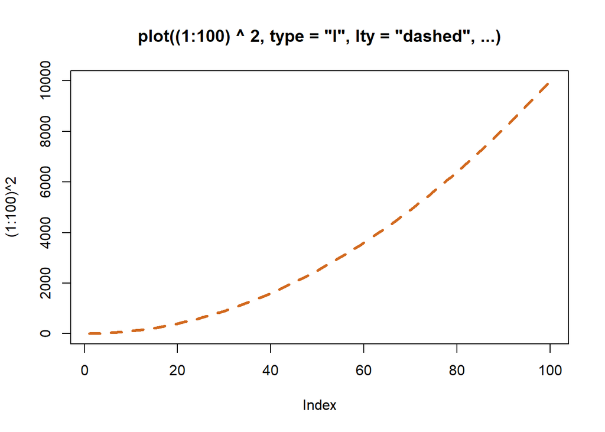

```r
plot(
  (1:100) ^ 2,
  type = "l",
  lty  = "dashed",
  lwd  = 3,
  col  = "chocolate",
  main = 'plot((1:100) ^ 2, type = "l", lty = "dashed", ...)'
)
```

##### 4.1.3 par()

- 그래프의 모양을 다양하게 조절할 수 있는 그래픽 인수들을 설정하고 조회하는 함수
- mfrow / mfcol : 한 화면에 여러 그래프를 비교해볼 때 사용
  - figure region을 나누어 plot region을 만들고 배치 순서를 정하는 인수
  - mfrow : 그래프를 행 우선 배치 default = c(1,1)
  - mfcol : 그래플르 열 우선 배치 default = c(1,1)

```r
w = c("Sun", "Mon", "Tue", "Wen", "Thu", "Fri", "Sat")
num = c(22,27,26,24,23,26,28)
names(num) = w
num
```

```
## Sun Mon Tue Wen Thu Fri Sat
##  22  27  26  24  23  26  28
```

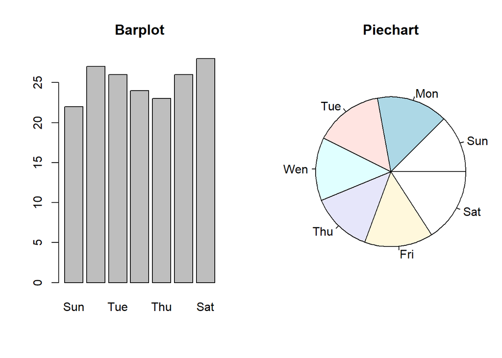

```r
par(mfrow=c(1,2))    # set the plotting area into a 1*2 array
barplot(num, main="Barplot")
pie(num, main="Piechart", radius=1)
```

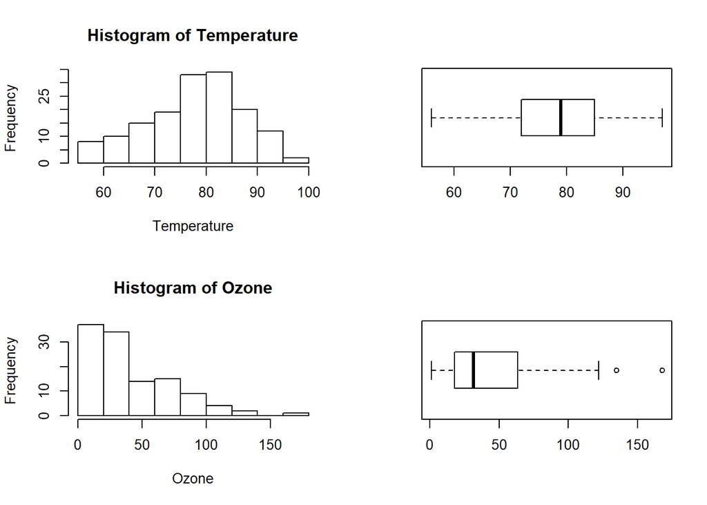

```r
Temperature <- airquality$Temp
Ozone <- airquality$Ozone
par(mfrow=c(2,2))
hist(Temperature)
boxplot(Temperature, horizontal=TRUE)
hist(Ozone)
boxplot(Ozone, horizontal=TRUE)
```